# Travailler avec les tibbles

## Bienvenue

Dans ce module, vous allez explorer la popularité de différents prénoms au fil du temps. Pour réussir cette tâche, vous devrez maîtriser certains outils courants pour manipuler les données avec R :

- `select()` et `filter()`, qui permettent de selectionner des colonnes et des lignes d’un jeu de données
- `arrange()`, qui vous permet de réordonner les lignes d’un jeu de données
- `%>%`, qui organise votre code sous la forme de “pipes” faciles à déchiffer (un pipe peut être vu comme un flux dans lequel divers traitements sur les données sont enchaînés)
- `mutate()`, `group_by()`, et `summarize()`, servent à calculer des statistiques descriptives

Ce sont quelques-unes des fonctions R les plus utiles pour la data science, et les modules qui suivent vous fourniront tout ce dont vous avez besoin pour apprendre à les manipuler.

Dans les modules, nous utiliserons un jeu de données nommé `prenoms`, qui est fourni dans le package également nommé **{prenoms}** made in ThinkR (voir [ici](https://github.com/ThinkR-open/prenoms) pour l’installer). Dans `prenoms`, vous trouverez des informations sur presque tous les prénoms donnés aux enfants en France métropolitaine depuis 1900.

Ce module présente `prenoms` ainsi qu’une nouvelle structure de données qui facilite l’utilisation des données dans R : **le tibble.**

En plus de `{prenoms}`, ce module utilise les [packages de base du tidyverse](http://tidyverse.org/), notamment {ggplot2}, {tibble} et {dplyr}. Tous ces packages ont été préinstallés mais ils n’ont pas été préchargés.

Cliquez sur le bouton “Suivant” pour commencer.

## Data Science avec les Prenoms

### La popularité d’un prénom au cours du temps

Nous avons au préalable modifié pour les besoins du cours les données de `prenoms` (comparé à celles disponibles dans le package) pour faciliter les tâches qui viennent. Voici maintenant le format des données `prenoms` (`prop` représente la proportion de bébés d’un sexe donné qui ont eu ce prénom cette année précise) :

| year | sex | name | n | prop |
| --- | --- | --- | --- | --- |
| 1981 | M | Abd | 4 | 1.058913e-05 |
| 1981 | M | Abdallah | 29 | 7.677116e-05 |
| 1981 | M | Abdel | 61 | 1.614842e-04 |
| 1981 | M | Abdelali | 3 | 7.941845e-06 |
| 1981 | M | Abdelaziz | 23 | 6.088747e-05 |
| 1981 | M | Abdelghani | 7 | 1.853097e-05 |
| 1981 | M | Abdelhafid | 8 | 2.117825e-05 |
| 1981 | M | Abdelhak | 10 | 2.647282e-05 |
| 1981 | M | Abdelhakim | 12 | 3.176738e-05 |
| 1981 | M | Abdelhamid | 6 | 1.588369e-05 |

[output cut: 9990 more lines]

Vous pouvez utiliser les données de `prenoms` pour créer des graphiques comme celui-ci, qui révèlent la popularité d’un prénom au cours du temps, peut-être votre prénom.

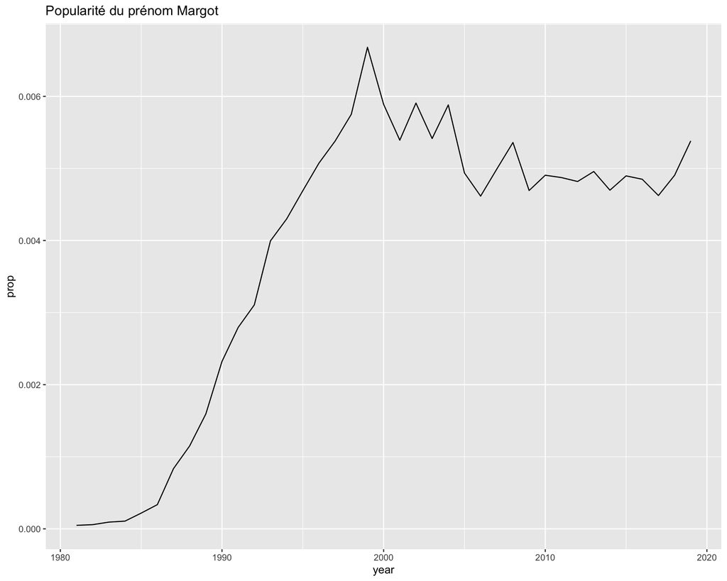

Votre objectif dans cette section est de répéter ce processus pour un autre prénom, par exemple le votre. En cours de route, vous apprendrez un ensemble de fonctions qui isolent les informations dans un jeu de données.

### Isoler des données

Ce type de tâche se produit souvent en Data science : vous devez extraire les données d’une table avant de pouvoir l’utiliser. Vous pouvez effectuer cette tâche rapidement avec trois fonctions fournies dans le package {dplyr} :

1. **select()** - qui selectionne des colonnes d’un jeu de données
2. **filter()** - qui extrait des lignes d’un jeu de données
3. **arrange()** - qui déplace les lignes importantes vers le haut d’un jeu de données

Chaque fonction prend un data.frame ou un tibble et renvoie un nouveau data.frame ou un tibble en sortie.

## select()

`select()` selectionne les colonnes d’un jeu de données et retourne les colonnes comme un nouveau jeu de données. Pour utiliser `select()`, passez-lui le nom du jeu de données dont extraire les colonnes, puis les noms des colonnes à extraire.

Aparté pour les déjà utilisateurs de R qui découvriraient le tidyverse : les noms de colonnes n’ont pas besoin d’apparaître entre guillemets ni d’être précédés par un `$`. En effet, `select()` sait les trouver dans le jeu de données que vous lui fournissez.

### Exercice - select()

Utilisez l’exemple ci-dessous pour avoir une idée du fonctionnement de `select()`. Pouvez-vous sélectionner uniquement la colonne `name` ? Et comment extraire `name` et `year` ? Que diriez-vous de sélectionner toutes les colonnes *sauf* `prop` ?

| name | year |
| --- | --- |
| Abd | 1981 |
| Abdallah | 1981 |
| Abdel | 1981 |
| Abdelali | 1981 |
| Abdelaziz | 1981 |
| Abdelghani | 1981 |
| Abdelhafid | 1981 |
| Abdelhak | 1981 |
| Abdelhakim | 1981 |
| Abdelhamid | 1981 |

[output cut: 9990 more lines]

### Outils de select()

Il existe également utiliser une série d’outils appelé “helpers” fournis avec `select()` et destinés à nous faciliter la vie. Par exemple, si vous placez un signe ‘-’ devant un nom de colonne, `select()` renverra toutes les colonnes sauf cette colonne. Pouvez-vous prédire comment le signe moins va fonctionner ici ?

| sex | name | n |
| --- | --- | --- |
| M | Abd | 4 |
| M | Abdallah | 29 |
| M | Abdel | 61 |
| M | Abdelali | 3 |
| M | Abdelaziz | 23 |
| M | Abdelghani | 7 |
| M | Abdelhafid | 8 |
| M | Abdelhak | 10 |
| M | Abdelhakim | 12 |
| M | Abdelhamid | 6 |

[output cut: 9990 more lines]

Le tableau ci-dessous résume les autres outils de `select()` disponibles dans {dplyr}. Étudiez-le, puis cliquez sur “Continue” pour tester votre compréhension.

| Outil | Utilisation | Exemple |
| --- | --- | --- |
| **-** | Exclusion de colonnes | `select(prenoms, -sex)` |
| **:** | Sélection des colonnes entre 2 colonnes spécifiques (inclusive) | `select(prenoms, year:n)` |
| **contains()** | Sélection des colonnes qui contiennent une chaîne de caractère spécifique | `select(prenoms, contains("n"))` |
| **ends_with()** | Sélection des colonnes qui se terminent par une chaîne de caractère spécifique | `select(prenoms, ends_with("n"))` |
| **matches()** | Sélection des colonnes qui correspondent à une expression réguliere | `select(prenoms, matches("n"))` |
| **num_range()** | Sélection des colonnes avec un suffixe numérique dans l’étendue demandée | Pas applicable à `prenoms` |
| **one_of()** | Sélection des colonnes dont le nom apparaît dans l’ensemble demandé | `select(prenoms, one_of(c("sex", "name")))` |
| **starts_with()** | Sélection des colonnes qui commencent par une chaîne de caractère spécifique | `select(prenoms, starts_with("n"))` |

## filter()

`filter()` extrait les lignes d’un jeu de données et les renvoie comme un nouveau jeu de données. Comme avec `select()`, le premier argument de `filter()` doit être un jeu de données dont on souhaite extraire des lignes. Les arguments qui suivent doivent être des tests logiques : `filter()` renverra chaque ligne pour laquelle les tests renverront `TRUE` (c’est-à-dire pour lesquelles la condition que l’on teste est vérifiée).

### filter() en action

Par exemple, le bloc de code ci-dessous renvoie chaque ligne avec le prénom “Annie” dans `prenoms`.

```r
filter(prenoms, name == "Annie")
```

| year | sex | name | n | prop |
| --- | --- | --- | --- | --- |
| 1981 | F | Annie | 172 | 4.926391e-04 |
| 1982 | F | Annie | 133 | 3.862024e-04 |
| 1983 | F | Annie | 85 | 2.643594e-04 |
| 1984 | F | Annie | 84 | 2.571080e-04 |
| 1985 | F | Annie | 103 | 3.120919e-04 |
| 1986 | F | Annie | 45 | 1.348541e-04 |
| 1987 | F | Annie | 53 | 1.610233e-04 |
| 1988 | F | Annie | 49 | 1.487639e-04 |
| 1989 | F | Annie | 60 | 1.835042e-04 |
| 1990 | F | Annie | 38 | 1.176777e-04 |

[output cut: 23 more lines]

### Tests logiques

Pour tirer le meilleur parti du filtre, vous devrez savoir comment utiliser les opérateurs de test logique de R, qui sont résumés ci-dessous.

| Opérateur logique | Tests | Exemple |
| --- | --- | --- |
| **>** | `x` est-il supérieur que `y` ? | `x > y` |
| **>=** | `x` est-il supérieur ou égal à `y` ? | `x >= y` |
| **<** | `x` est-il inférieur à `y` ? | `x < y` |
| **<=** | `x` est-il inférieur ou égale à `y` ? | `x <= y` |
| **==** | `x` est-il égal à `y` ? | `x == y` |
| **!=** | `x` est-il différent de `y` ? | `x != y` |
| **is.na()** | `x` est-il une information manquante `NA` ? | `is.na(x)` |
| **!is.na()** | `x` n’est pas une information manquante `NA`? | `!is.na(x)` |

### Exercice - Opérateurs logiques

Voyez si vous pouvez utiliser les opérateurs logiques pour manipuler le code ci-dessous pour afficher :

- Tous les prénoms pour lequels `prop` est supérieure ou égale à 0.08
- Tous les enfants prénommés “Paulette”
- Tous les prénoms qui ont une valeur manquante pour `n` (Astuce : cela devrait retourner un ensemble de données vide).

| year | sex | name | n | prop |
| --- | --- | --- | --- | --- |
| 1981 | F | Annie | 172 | 4.926391e-04 |
| 1982 | F | Annie | 133 | 3.862024e-04 |
| 1983 | F | Annie | 85 | 2.643594e-04 |
| 1984 | F | Annie | 84 | 2.571080e-04 |
| 1985 | F | Annie | 103 | 3.120919e-04 |
| 1986 | F | Annie | 45 | 1.348541e-04 |
| 1987 | F | Annie | 53 | 1.610233e-04 |
| 1988 | F | Annie | 49 | 1.487639e-04 |
| 1989 | F | Annie | 60 | 1.835042e-04 |
| 1990 | F | Annie | 38 | 1.176777e-04 |

[output cut: 23 more lines]

| year | sex | name | n | prop |
| --- | --- | --- | --- | --- |

| year | sex | name | n | prop |
| --- | --- | --- | --- | --- |

| year | sex | name | n | prop |
| --- | --- | --- | --- | --- |

### Deux erreurs courantes

```r
filter(prenoms, name = "Annie")
```

```r
filter(prenoms, name == Annie)
```

### Deux erreurs - Récapitulatif

Lorsque vous utilisez des tests logiques, veillez à rechercher ces deux erreurs courantes :

1. utiliser `=` au lieu de `==` pour tester l’égalité
2. oublier d’utiliser des guillemets lors de la comparaison de chaînes, par ex. `name == Marie`, au lieu de`name == "Marie"`.

### Combinaison de tests

Si vous fournissez plus d’un test à `filter()`, `filter()` combinera les tests avec une instruction **et** (`&`) : il ne renverra que les lignes qui satisfont tous les tests.

Pour combiner plusieurs tests d’une manière différente, utilisez les opérateurs booléens de R. Par exemple, le code ci-dessous renverra tous les enfants prénommés Julie **ou** Antoinette.

```r
filter(prenoms, name == "Julie" | name == "Antoinette")
```

| year | sex | name | n | prop |
| --- | --- | --- | --- | --- |
| 1981 | F | Antoinette | 9 | 2.577763e-05 |
| 1981 | F | Julie | 6148 | 1.760898e-02 |
| 1982 | F | Antoinette | 9 | 2.613400e-05 |
| 1982 | F | Julie | 7192 | 2.088397e-02 |
| 1983 | F | Antoinette | 13 | 4.043143e-05 |
| 1983 | F | Julie | 8317 | 2.586679e-02 |
| 1984 | F | Antoinette | 12 | 3.672971e-05 |
| 1984 | F | Julie | 8448 | 2.585772e-02 |
| 1985 | F | Antoinette | 13 | 3.939024e-05 |
| 1985 | F | Julie | 8735 | 2.646721e-02 |

[output cut: 61 more lines]

### Opérateurs booléens

Vous pouvez trouver une liste complète des opérateurs booléens de base de R dans le tableau ci-dessous.

| Opérateur booléen | Signification | Exemple |
| --- | --- | --- |
| **&** | Est-ce que les conditions`A` et `B` sont *toutes les deux* vraies ? | `A & B` |
| `\|` | Est-ce que l’ *une ou les deux* conditions `A` et `B` sont vraies ? | `A \| B` |
| **!** | Est-ce que `A` *n’est pas* vraie ? | `!A` |
| **xor()** | Est-ce que l’ *une et uniquement une* des conditions `A` et `B` est vraie ? | `xor(A, B)` |
| **%in%** | Est-ce que `x` est dans l’ensemble `a`, `b`, et `c` ? | `x %in% c(a, b, c)` |
| **any()** | Est-ce que *l’une* des conditions `A`, `B`, ou `C` est vraie ? | `any(A, B, C)` |
| **all()** | Est-ce que *toutes* les conditions `A`, `B`, ou `C` sont vraies ? | `all(A, B, C)` |

### Exercice - Combinaison de tests

Utilisez les opérateurs booléens pour modifier le bloc de code ci-dessous pour renvoyer uniquement les lignes qui contiennent :

- Les *filles* prénommées Agnès
- Les prénoms qui ont été données à exactement 5 ou 6 enfants en 1990
- Les prénoms Marie, Mariette ou Marine

### Deux erreurs courantes supplémentaires

Les tests logiques peuvent également être liés à deux erreurs dréquentes que nous allons explorer. Chacune est affichée dans un bloc de code ci-dessous. L’un des codes génère une erreur et l’autre est inutilement verbeux. Diagnostiquez les problèmes, puis corrigez le code.

```r
filter(prenoms, 10 < n < 20)
```

```r
filter(prenoms, n == 5 | n == 6 | n == 7 | n == 8 | n == 9)
```

| year | sex | name | n | prop |
| --- | --- | --- | --- | --- |
| 1981 | M | Abdelghani | 7 | 1.853097e-05 |
| 1981 | M | Abdelhafid | 8 | 2.117825e-05 |
| 1981 | M | Abdelhamid | 6 | 1.588369e-05 |
| 1981 | M | Aboubacar | 5 | 1.323641e-05 |
| 1981 | M | Achraf | 6 | 1.588369e-05 |
| 1981 | M | Adile | 5 | 1.323641e-05 |
| 1981 | M | Adrian | 8 | 2.117825e-05 |
| 1981 | F | Adrienne | 6 | 1.718508e-05 |
| 1981 | F | Ahlam | 7 | 2.004926e-05 |
| 1981 | M | Aiman | 7 | 1.853097e-05 |

[output cut: 9990 more lines]

### Deux erreurs courantes supplémentaires - Récapitulatif

Lorsque vous combinez plusieurs tests logiques, veillez à rechercher ces deux erreurs courantes :

1. Réduire plusieurs tests logiques en un seul test *sans utiliser d’opérateur booléen*
2. Utilisation répétitive de `|` au lieu de `%in%`, par ex. `x == 1 | x == 2 | x == 3` au lieu de `x %in% c (1, 2, 3)`

## arrange()

`arrange()` renvoie toutes les lignes d’un jeu données réorganisées par les valeurs d’une colonne. Comme avec `select()`, le premier argument de `arrange()` doit être un jeu de données et les arguments restants sont les noms des colonnes.

Si vous donnez à `arrange()` un seul nom de colonne, il renverra les lignes du jeu de données réorganisées de sorte que la ligne avec la valeur la plus basse dans cette colonne apparaisse en premier, la ligne avec la deuxième valeur la plus basse apparaisse en deuxième, et ainsi de suite. Si la colonne contient des chaînes de caractères, `arrange()` les placera par ordre alphabétique.

### Exercice - arrange()

Utilisez le bloc de code ci-dessous pour organiser les prénoms en fonction de `n`. Pouvez-vous dire quelle est la plus petite valeur de `n`?

### Gestion des ex-aequo

Si vous renseignez plusieurs noms de colonnes, `arrange()` les utilisera successivement pour réorganiser les lignes qui ont des valeurs identiques dans les colonnes précédentes. Complétez le code ci-dessous avec la colonne `prop` pour illustrer ce fonctionnement. Le résultat doit d’abord classer les lignes en fonction de la valeur de `n`, puis réorganiser les lignes de chaque valeur de `n` en fonction des valeurs de `prop`.

| year | sex | name | n | prop |
| --- | --- | --- | --- | --- |
| 1981 | M | Francescu | 2 | 5.294563e-06 |
| 1981 | M | Ghjuvan | 2 | 5.294563e-06 |
| 1981 | M | Jean-André | 2 | 5.294563e-06 |
| 1981 | F | Paule | 2 | 5.728361e-06 |
| 1981 | F | Santa | 2 | 5.728361e-06 |
| 1981 | M | Toussaint | 2 | 5.294563e-06 |
| 1982 | M | Don | 2 | 5.367629e-06 |
| 1982 | M | Jean-Antoine | 2 | 5.367629e-06 |
| 1982 | F | Josepha | 2 | 5.807555e-06 |
| 1983 | F | Colomba | 2 | 6.220221e-06 |

[output cut: 9990 more lines]

### desc

Si vous préférez organiser les lignes dans l’ordre inverse, c’est-à-dire des valeurs *les plus grandes* aux valeurs *les plus petites*, entourez un nom de colonne avec la fonction `desc()`. `arrange()` réordonnera les lignes des plus grandes valeurs aux plus petites.

| year | sex | name | n | prop |
| --- | --- | --- | --- | --- |
| 1981 | M | Nicolas | 20827 | 5.513493e-02 |
| 1981 | M | Julien | 15059 | 3.986541e-02 |
| 1981 | M | Sébastien | 14654 | 3.879326e-02 |
| 1981 | F | Céline | 12504 | 3.581371e-02 |
| 1981 | F | Aurélie | 12362 | 3.540700e-02 |
| 1981 | F | Emilie | 10809 | 3.095893e-02 |
| 1981 | M | David | 9777 | 2.588247e-02 |
| 1981 | F | Virginie | 8890 | 2.546257e-02 |
| 1981 | F | Stéphanie | 8523 | 2.441141e-02 |
| 1981 | M | Guillaume | 8838 | 2.339667e-02 |

[output cut: 9990 more lines]

Vous pensez avoir compris ?

### Quiz arrange()

Quel prénom était le plus populaire pour un seul sexe en une seule année ? Dans le bloc de code ci-dessous, utilisez `arrange()` pour faire apparaître la ligne avec la plus grande valeur de `prop` en haut du jeu de données.

Arrangez maintenant `prenoms` pour que la ligne avec la plus grande valeur de `n` apparaisse en haut du jeu de données. Est-ce que ce sera la même ligne d’après vous ?

## slice()

Le verbe `slice()` sélectionne des lignes du tableau selon leur position. On lui passe un chiffre ou un vecteur de chiffres.

### Exercice - slice()

Utilisez le bloc de code ci-dessous pour sélectionner la 345e ligne du tableau `prenoms`.

| year | sex | name | n | prop |
| --- | --- | --- | --- | --- |
| 1981 | F | Carla | 42 | 0.0001202956 |

Si on veut sélectionner les 5 premières lignes :

| year | sex | name | n | prop |
| --- | --- | --- | --- | --- |
| 1981 | M | Abd | 4 | 1.058913e-05 |
| 1981 | M | Abdallah | 29 | 7.677116e-05 |
| 1981 | M | Abdel | 61 | 1.614842e-04 |
| 1981 | M | Abdelali | 3 | 7.941845e-06 |
| 1981 | M | Abdelaziz | 23 | 6.088747e-05 |

## Pipe `%>%`

### Étapes

Remarquez comment chaque fonction de {dplyr} prend un jeu de données en entrée et renvoie un jeu de données en sortie. Cela rend les fonctions faciles “brancher” les unes aux autres pour réaliser des suites d’étapes. Par exemple, vous pourriez :

1. Filtrer les prénoms de bébé pour les garçons nés en 2018
2. Sélectionner les colonnes `name` et `n` dans le résultat
3. Organiser ces colonnes de sorte que les prénoms les plus populaires apparaissent en haut.

```r
boys_2018 <- filter(prenoms, year == 2018, sex == "M")
boys_2018 <- select(boys_2018, name, n)
boys_2018 <- arrange(boys_2018, desc(n))
boys_2018
```

| name | n |
| --- | --- |
| Gabriel | 5421 |
| Raphaël | 4590 |
| Léo | 4446 |
| Louis | 4410 |
| Lucas | 3979 |
| Adam | 3886 |
| Arthur | 3751 |
| Jules | 3696 |
| Hugo | 3689 |
| Maël | 3260 |

[output cut: 2143 more lines]

### Redondance

Vous pouvez éviter de créer `boys_2018` à chaque fois. Pour cela, une première stratégie consiste à imbriquer vos fonctions les unes dans les autres. Cependant, cela crée du code difficile à lire :

```r
arrange(select(filter(prenoms, year == 2018, sex == "M"), name, n), desc(n))
```

Le package {dplyr} fournit une troisième façon d’écrire des séquences de fonctions : le pipe %>%. Le pipe peut être vu comme un flux, dans lequel nous réalisons une série d’opérations sur les données.

### %>%

L’opérateur pipe `%>%` effectue la tâche suivante : il passe l’objet à gauche en premier argument de la fonction à droite. Ou en d’autres termes, `x %>% f(y)` est identique à `f(x, y)`. Cette manière d’écrire du code facilite l’écriture et la lecture d’une série de fonctions qui sont appliquées étape par étape. Par exemple, nous pouvons utiliser le pipe pour réécrire notre code ci-dessus :

```r
prenoms %>%
  filter(year == 2018, sex == "M") %>%
  select(name, n) %>%
  arrange(desc(n))
```

| name | n |
| --- | --- |
| Gabriel | 5421 |
| Raphaël | 4590 |
| Léo | 4446 |
| Louis | 4410 |
| Lucas | 3979 |
| Adam | 3886 |
| Arthur | 3751 |
| Jules | 3696 |
| Hugo | 3689 |
| Maël | 3260 |

[output cut: 2143 more lines]

{dplyr} facilite également l’écriture des pipes. Chaque fonction de {dplyr} renvoie un jeu de données qui peut être utilisé dans une autre fonction de {dplyr} (qui acceptera alors le jeu de données comme premier argument). En fait, les fonctions de dplyr sont écrites pour permettre l’usage du pipe : chaque fonction fait une tâche simple, et {dplyr} s’attend à ce que vous utilisiez des pipes pour combiner ces tâches simples pour produire des résultats plus sophistiqués.

### Exercice - Pipes

Nous utiliserons des pipes pour le reste du module. Pratiquons un peu en écrivant un nouveau pipe dans le code ci-dessous. Le flux de traitement doit être le suivant :

1. Filtrer les prénoms de bébé uniquement pour les *filles* nées en 2018
2. Sélectionner les colonnes `name` et `n`
3. Organiser les résultats de manière à ce que les prénoms les plus populaires soient en haut dans le résultat.

Essayez d’écrire votre propre pipe, sans copier ni coller le code ci-dessus.

### Tester un autre prénom

Vous maîtrisez maintenant un ensemble de compétences qui vont vous permettre de tracer facilement la popularité de n’importe quel prénom au fil du temps (pourquoi pas le votre ?). Dans le bloc de code ci-dessous, utilisez une combinaison de fonctions de {dplyr} et de {ggplot2} avec `%>%` pour :

1. Réduire `prenoms` aux seules lignes qui contiennent le prénom et le sexe que vous souhaitez étudier
2. Réduire le résultat aux seules colonnes qui apparaîtront dans votre graphique (pas strictement nécessaire, mais pratique pour avoir une meilleure visibilité)
3. Tracer les résultats sous la forme d’un graphique linéaire avec `year` sur l’axe des x et `prop` sur l’axe des y

Notez que le premier argument de `ggplot()` est un jeu de données. Cela signifie que vous pouvez ajouter `ggplot()` directement à la fin d’un pipe. Cependant, vous devrez passer de `%>%` à `+` pour terminer l’ajout de couches à votre graphique.

### Récapitulatif

Ensemble, `select()`, `filter()` et `arrange()` vous permettent de trouver rapidement les informations disponibles dans vos données.

Le module suivant vous montrera comment calculer des informations implicites dans vos données, mais non disponibles telles quelles dans le jeu de données.

Dans ce module, vous continuerez à utiliser l’opérateur `%>%`, qui est une partie essentielle de la programmation dans le tidyverse. Dans le tidyverse, les fonctions sont comme des verbes : chacune accomplit une tâche simple. Vous pouvez combiner ces tâches en un flux de traitements avec `%>%` pour effectuer des procédures complexes et personnalisées. C’est ainsi que les pipes contribuent à rendre R intelligible, comme une langue parlée. Les langues parlées sont en effet constituées de mots simples que vous combinez en phrases complexes pour créer des pensées sophistiquées.